# Module 18

#### Hemi-module gene counts:

417 probesets in hemi-module A.  
26 probesets in hemi-module B.  
Note: While the mapping of probesets to genes is usually one-to-one, some genes are targeted by multiple probesets, some probesets target multiple genes, and some probesets do not target any genes (i.e., the region of the genome they match is no longer considered genic).

#### Contrast SVE:

Signed variance explained (SVE) provides an indication of how similar a set of fold changes are to a gene module’s weight vector. An SVE value of 0.3, for example, indicates that 30% of the variance explained by the entire module set is accounted for by the module in question. Shown here are the SVE values for this module across a compendium of fold changes (contrasts). Extreme SVE values (e.g., > 0.05) indicate that those contrasts specifically induce (orange dots) or specifically repress (blue dots) this module. Examining the experimental conditions being compared in such contrasts (see tables below the figure) may provide insight into the gene module’s function.

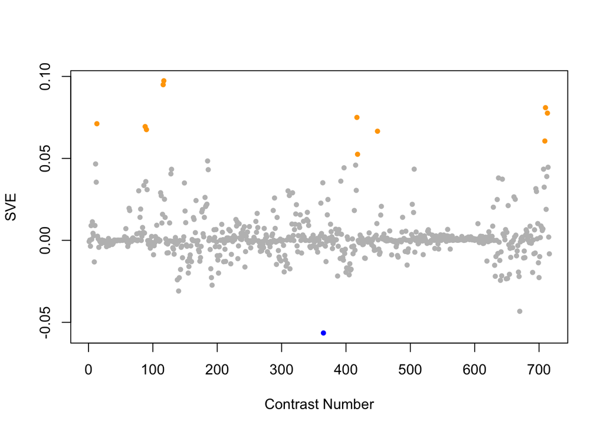

Positive SVE Contrasts:

|  | Contrast.Num | SVE | GEO.GSE | Cond.1 | Cond.2 | Mutation |
| --- | --- | --- | --- | --- | --- | --- |
| GSE54024.s3t1.vs.s6t1 | 117 | 0.10 | GSE54024 | nuo-6(qm200) young adults, biological rep 1 | isp-1(qm150) ced-4(n1162) double mutant young adults, biological rep 1 |  |
| GSE54024.s4t1.vs.s6t1 | 116 | 0.09 | GSE54024 | isp-1(qm150) young adults, biological rep 1 | isp-1(qm150) ced-4(n1162) double mutant young adults, biological rep 1 | ced-4 |
| GSE11055.s2t6.vs.s2t2 | 710 | 0.08 | GSE11055 | L1 larvae 12 hr after hatching in the absence of food | L1 larvae 0 hr after hatching in the absence of food |  |
| GSE11055.s2t4.vs.s2t2 | 713 | 0.08 | GSE11055 | L1 larvae 3 hr after hatching in the absence of food | L1 larvae 0 hr after hatching in the absence of food |  |
| GSE28856.s0t2.vs.s0t1 | 417 | 0.07 | GSE28856 | Wild-type 1 h after shifting temperature rep1 | Wild-type 0 h after shifting temperature rep1 |  |
| GSE9682.s2t2.vs.s0t2 | 13 | 0.07 | GSE9682 | N2-Cel-TORRNAi-fed-biological rep1 | N2-controlRNAi-fed-biological rep1 | TOR |
| GSE6547.s0t2.vs.s0t1 | 88 | 0.07 | GSE6547 | N2 (wt) worms at L1 stage, first replicate | N2 (wt) worms at embryonic stage, first replicate |  |
| GSE6547.s1t2.vs.s1t1 | 90 | 0.07 | GSE6547 | lin-35(n745) worms at L1 stage, first replicate | lin-35(n745) worms at embryonic stage, first replicate |  |
| GSE25831.s1t1.vs.s2t1 | 449 | 0.07 | GSE25831 | WT_fedL1_rep1 | mixed embryo XX_WT-N_080307_A |  |
| GSE11055.s2t3.vs.s2t2 | 709 | 0.06 | GSE11055 | L1 larvae 1 hr after hatching in the absence of food | L1 larvae 0 hr after hatching in the absence of food |  |
| GSE28856.s0t3.vs.s0t1 | 418 | 0.05 | GSE28856 | Wild-type 2 h after shifting temperature rep1 | Wild-type 0 h after shifting temperature rep1 |  |

Negative SVE Contrasts:

|  | Contrast.Num | SVE | GEO.GSE | Cond.1 | Cond.2 | Mutation |
| --- | --- | --- | --- | --- | --- | --- |
| GSE36358.s3t1.vs.s0t1 | 365 | -0.06 | GSE36358 | Hyper Gravity | Ground Control (Tsukuba space center) |  |
| GSE15016.s2t1.vs.s0t1 | 670 | -0.04 | GSE15016 | young adult_24hr NP exposure_rep1 | young adult_not exposured_rep1 |  |
| GSE51691.s4t1.vs.s2t1 | 140 | -0.03 | GSE51691 | day8 hermaphrodite utx-1 RNAi +males rep 1 | day8 hermaphrodite +males rep 1 | utx-1(RNAi) |
| GSE45651.s1t1.vs.s0t1 | 192 | -0.03 | GSE45651 | starved L1 lin-35(n745), biological rep1 | starved L1 wild type worm, biological rep1 | lin-35 |
| GSE18132.s2t2.vs.s2t1 | 640 | -0.02 | GSE18132 | Oga Fed L4, biological replicate 1 | Oga starved L1, biological replicate 1 |  |

$~$

#### Contrast SVE, Up-Regulated Genes Only:

Calculating SVE for up-regulated and down-regulated genes separately may be more informative in many cases than projecting the up- and down- gene sets together. This is due to the fact that the weight distribution of many modules is highly skewed, indicating that only one of the hemi-modules may be biologically meaningful (i.e., a set of genes are strongly correlated by only a few genes (or none) are strongly anti-correlated to that set.)

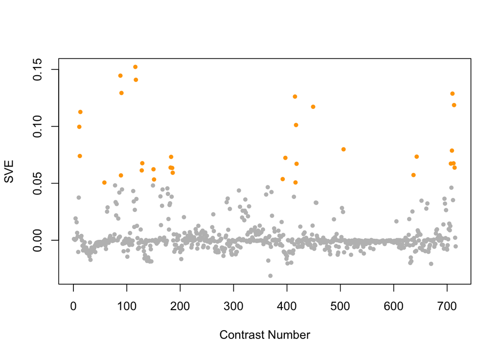

Positive SVE Contrasts:

|  | Contrast.Num | SVE | GEO.GSE | Cond.1 | Cond.2 | Mutation |
| --- | --- | --- | --- | --- | --- | --- |
| GSE54024.s4t1.vs.s6t1 | 116 | 0.15 | GSE54024 | isp-1(qm150) young adults, biological rep 1 | isp-1(qm150) ced-4(n1162) double mutant young adults, biological rep 1 | ced-4 |
| GSE6547.s0t2.vs.s0t1 | 88 | 0.14 | GSE6547 | N2 (wt) worms at L1 stage, first replicate | N2 (wt) worms at embryonic stage, first replicate |  |
| GSE54024.s3t1.vs.s6t1 | 117 | 0.14 | GSE54024 | nuo-6(qm200) young adults, biological rep 1 | isp-1(qm150) ced-4(n1162) double mutant young adults, biological rep 1 |  |
| GSE6547.s1t2.vs.s1t1 | 90 | 0.13 | GSE6547 | lin-35(n745) worms at L1 stage, first replicate | lin-35(n745) worms at embryonic stage, first replicate |  |
| GSE11055.s2t6.vs.s2t2 | 710 | 0.13 | GSE11055 | L1 larvae 12 hr after hatching in the absence of food | L1 larvae 0 hr after hatching in the absence of food |  |
| GSE29951.s1t2.vs.s1t1 | 415 | 0.13 | GSE29951 | C.elegans MT KO mtl-1,mtl-2(zs1) raised in the presence of Cd, rep1 | C.elegans MT KO mtl-1,mtl-2(zs1), raised in the absence of Cd, rep1 | mtl-1;mtl-2 |
| GSE11055.s2t4.vs.s2t2 | 713 | 0.12 | GSE11055 | L1 larvae 3 hr after hatching in the absence of food | L1 larvae 0 hr after hatching in the absence of food |  |
| GSE25831.s1t1.vs.s2t1 | 449 | 0.12 | GSE25831 | WT_fedL1_rep1 | mixed embryo XX_WT-N_080307_A |  |
| GSE9682.s2t2.vs.s0t2 | 13 | 0.11 | GSE9682 | N2-Cel-TORRNAi-fed-biological rep1 | N2-controlRNAi-fed-biological rep1 | TOR |
| GSE28856.s0t2.vs.s0t1 | 417 | 0.10 | GSE28856 | Wild-type 1 h after shifting temperature rep1 | Wild-type 0 h after shifting temperature rep1 |  |
| GSE9682.s2t1.vs.s0t1 | 11 | 0.10 | GSE9682 | N2-Cel-TORRNAi-fasting-biological rep1 | N2-controlRNAi-fasting-biological rep1 | TOR |
| GSE2210.s1t1.vs.s0t1 | 506 | 0.08 | GSE2210 | tom-1(nu468) Sample 1 | Wild type Sample 1 | tom-1 |
| GSE11055.s2t3.vs.s2t2 | 709 | 0.08 | GSE11055 | L1 larvae 1 hr after hatching in the absence of food | L1 larvae 0 hr after hatching in the absence of food |  |
| GSE9682.s1t2.vs.s0t2 | 12 | 0.07 | GSE9682 | N2-Cel-RhebRNAi-fed-biological rep1 | N2-controlRNAi-fed-biological rep1 | Rheb |
| GSE16975.s1t1.vs.s0t1 | 643 | 0.07 | GSE16975 | C.elegans hydrogen sulfide sample replicate 1 | C.elegans control sample replicate 1 |  |
| GSE47778.s1t3.vs.s1t1 | 183 | 0.07 | GSE47778 | N2; UV; replicate 1 | N2; replicate 1 |  |
| GSE30505.s3t2.vs.s4t2 | 397 | 0.07 | GSE30505 | Day 8 glp-1 E.V. #1 | Day 8 glp-1 ash-2 #1 | ash-2 |
| GSE54011.s4t1.vs.s0t1 | 129 | 0.07 | GSE54011 | Ce 0.4 mM Se | Ce 0 mM Se |  |
| GSE11055.s2t8.vs.s2t2 | 712 | 0.07 | GSE11055 | L1 larvae 24 hr after hatching in the absence of food | L1 larvae 0 hr after hatching in the absence of food |  |
| GSE11055.s1t7.vs.s1t1 | 707 | 0.07 | GSE11055 | L1-L2 larvae 15 hr after hatching in the presence of food | embryo 2 hr before hatching |  |
| GSE28856.s0t3.vs.s0t1 | 418 | 0.07 | GSE28856 | Wild-type 2 h after shifting temperature rep1 | Wild-type 0 h after shifting temperature rep1 |  |
| GSE47778.s1t2.vs.s1t1 | 182 | 0.06 | GSE47778 | N2; starvation; replicate 1 | N2; replicate 1 |  |
| GSE11055.s2t5.vs.s2t2 | 714 | 0.06 | GSE11055 | L1 larvae 6 hr after hatching in the absence of food | L1 larvae 0 hr after hatching in the absence of food |  |
| GSE4766.s1t3.vs.s1t1 | 185 | 0.06 | GSE4766 | Pooled glp-1 C elegans old adults_rep1 | Pooled glp-1 C elegans embryos_bleach NaOH prep_rep1 |  |
| GSE47778.s2t1.vs.s3t1 | 150 | 0.06 | GSE47778 | daf-2; replicate 1 | daf-16; replicate 1 | daf-2 vs. daf-16 |
| GSE54011.s3t1.vs.s0t1 | 128 | 0.06 | GSE54011 | Ce 0.2 mM Se | Ce 0 mM Se |  |
| GSE4766.s1t2.vs.s1t1 | 186 | 0.06 | GSE4766 | Pooled glp-1 C elegans young adults_rep1 | Pooled glp-1 C elegans embryos_bleach NaOH prep_rep1 |  |
| GSE18132.s1t2.vs.s0t2 | 637 | 0.06 | GSE18132 | Ogt Fed L4, biological replicate 1 | WT Fed L4, biological rep1 | ogt-1 |
| GSE6547.s0t3.vs.s0t1 | 89 | 0.06 | GSE6547 | N2 (wt) worms at L4 stage, first replicate | N2 (wt) worms at embryonic stage, first replicate |  |
| GSE32339.s1t2.vs.s0t2 | 392 | 0.05 | GSE32339 | Adult Mutant, biological rep1 | Adult Wild-type, biological rep1 | nep-1 |
| GSE47778.s4t1.vs.s3t1 | 151 | 0.05 | GSE47778 | daf-2;daf-16; replicate 1 | daf-16; replicate 1 | daf-2;daf-16 vs. daf-16 |
| GSE29951.s0t2.vs.s0t1 | 416 | 0.05 | GSE29951 | C.elegans wild type raised in the presence of Cd, rep1 | C.elegans wild type raised in the absence of Cd, rep1 |  |
| GSE9485.s2t1.vs.s1t1 | 58 | 0.05 | GSE9485 | Larval Reference, biological rep 1 | Larval Pan-neural, biological rep 1 |  |

Negative SVE Contrasts:

|  | Contrast.Num | SVE | GEO.GSE | Cond.1 | Cond.2 | Mutation |
| --- | --- | --- | --- | --- | --- | --- |
| GSE35360B.s1t1.vs.s0t1 | 369 | -0.03 | GSE35360 | HF 3d_0.2_rep1 | HF 3d control_rep1 |  |
| GSE15016.s2t1.vs.s0t1 | 670 | -0.02 | GSE15016 | young adult_24hr NP exposure_rep1 | young adult_not exposured_rep1 |  |
| GSE30505.s1t2.vs.s3t2 | 401 | -0.02 | GSE30505 | Day 8 N2 (WT) E.V. #1 | Day 8 glp-1 E.V. #1 | glp-1 |
| GSE19310B.s1t4.vs.s1t1 | 631 | -0.02 | GSE19310 | N2 at 200 for 1 generation, rep1 | N2 at 200 for 15min, rep1 |  |
| GSE30505.s1t1.vs.s2t1 | 408 | -0.02 | GSE30505 | L3 N2 (WT) E.V. #1 | L3 N2 (WT) ash-2 #1 | ash-2 |

$~$

#### Contrast SVE, Down-Regulated Genes Only:

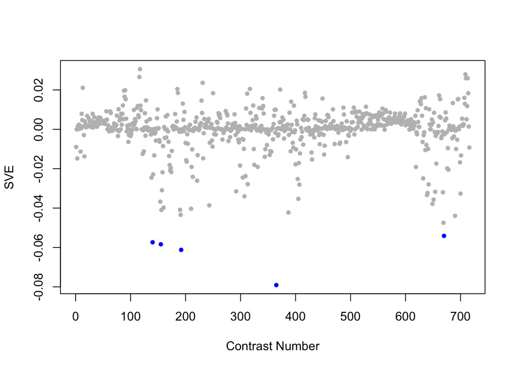

Positive SVE Contrasts:

|  | Contrast.Num | SVE | GEO.GSE | Cond.1 | Cond.2 | Mutation |
| --- | --- | --- | --- | --- | --- | --- |
| GSE54024.s3t1.vs.s6t1 | 117 | 0.03 | GSE54024 | nuo-6(qm200) young adults, biological rep 1 | isp-1(qm150) ced-4(n1162) double mutant young adults, biological rep 1 |  |
| GSE11055.s2t3.vs.s2t2 | 709 | 0.03 | GSE11055 | L1 larvae 1 hr after hatching in the absence of food | L1 larvae 0 hr after hatching in the absence of food |  |
| GSE54024.s4t1.vs.s6t1 | 116 | 0.03 | GSE54024 | isp-1(qm150) young adults, biological rep 1 | isp-1(qm150) ced-4(n1162) double mutant young adults, biological rep 1 | ced-4 |
| GSE11055.s2t4.vs.s2t2 | 713 | 0.03 | GSE11055 | L1 larvae 3 hr after hatching in the absence of food | L1 larvae 0 hr after hatching in the absence of food |  |
| GSE11055.s2t6.vs.s2t2 | 710 | 0.03 | GSE11055 | L1 larvae 12 hr after hatching in the absence of food | L1 larvae 0 hr after hatching in the absence of food |  |

Negative SVE Contrasts:

|  | Contrast.Num | SVE | GEO.GSE | Cond.1 | Cond.2 | Mutation |
| --- | --- | --- | --- | --- | --- | --- |
| GSE36358.s3t1.vs.s0t1 | 365 | -0.08 | GSE36358 | Hyper Gravity | Ground Control (Tsukuba space center) |  |
| GSE45651.s1t1.vs.s0t1 | 192 | -0.06 | GSE45651 | starved L1 lin-35(n745), biological rep1 | starved L1 wild type worm, biological rep1 | lin-35 |
| GSE47778.s1t1.vs.s2t1 | 155 | -0.06 | GSE47778 | N2; replicate 1 | daf-2; replicate 1 | daf-2 |
| GSE51691.s4t1.vs.s2t1 | 140 | -0.06 | GSE51691 | day8 hermaphrodite utx-1 RNAi +males rep 1 | day8 hermaphrodite +males rep 1 | utx-1(RNAi) |
| GSE15016.s2t1.vs.s0t1 | 670 | -0.05 | GSE15016 | young adult_24hr NP exposure_rep1 | young adult_not exposured_rep1 |  |

$~$

$~$

#### GO Term Enrichment:

This analysis tests each hemi-module for enrichment of specific GO terms. Only gene-level annotations (e.g., as would be found on the gene’s page in Wormbase) are tested - the hierarchical structure of the GO ontology is not taken into account.

*Note: At least the top two most enriched terms from each GO domain (BP/MF/CC) are shown, even when not statistically significant.*

##### Enriched GO terms: Hemi-module A

| ID | GO.Term | GO Domain | Raw p-value | Adj p-value |
| --- | --- | --- | --- | --- |
| [GO_0007218](http://amigo.geneontology.org/amigo/term/GO:0007218) | neuropeptide signaling pathway | BP | 4.88e-26 | 1.78e-22 |
| [GO_1905905](http://amigo.geneontology.org/amigo/term/GO:1905905) | pharyngeal gland morphogenesis | BP | 2.41e-07 | 4.38e-04 |
| [GO_1905910](http://amigo.geneontology.org/amigo/term/GO:1905910) | negative regulation of dauer entry | BP | 5.43e-06 | 6.59e-03 |
| [GO_0006936](http://amigo.geneontology.org/amigo/term/GO:0006936) | muscle contraction | BP | 2.23e-05 | 2.03e-02 |
| [GO_0008582](http://amigo.geneontology.org/amigo/term/GO:0008582) | regulation of synaptic growth at neuromuscular junction | BP | 3.64e-05 | 2.65e-02 |
| [GO_0005179](http://amigo.geneontology.org/amigo/term/GO:0005179) | hormone activity | MF | 1.32e-10 | 2.70e-07 |
| [GO_0071855](http://amigo.geneontology.org/amigo/term/GO:0071855) | neuropeptide receptor binding | MF | 1.63e-07 | 1.67e-04 |
| [GO_0030246](http://amigo.geneontology.org/amigo/term/GO:0030246) | carbohydrate binding | MF | 1.44e-05 | 9.78e-03 |
| [GO_0005576](http://amigo.geneontology.org/amigo/term/GO:0005576) | extracellular region | CC | 9.34e-19 | 8.67e-16 |
| [GO_0005634](http://amigo.geneontology.org/amigo/term/GO:0005634) | nucleus | CC | 2.56e-13 | 1.19e-10 |
| [GO_0005615](http://amigo.geneontology.org/amigo/term/GO:0005615) | extracellular space | CC | 8.61e-07 | 2.66e-04 |
| [GO_0005737](http://amigo.geneontology.org/amigo/term/GO:0005737) | cytoplasm | CC | 1.26e-04 | 2.92e-02 |

##### Enriched GO terms: Hemi-module B

| ID | GO.Term | GO Domain | Raw p-value | Adj p-value |
| --- | --- | --- | --- | --- |
| [GO_0030207](http://amigo.geneontology.org/amigo/term/GO:0030207) | chondroitin sulfate catabolic process | BP | 1.41e-03 | 1.00e+00 |
| [GO_0048620](http://amigo.geneontology.org/amigo/term/GO:0048620) | post-embryonic hindgut morphogenesis | BP | 1.41e-03 | 1.00e+00 |
| [GO_0004415](http://amigo.geneontology.org/amigo/term/GO:0004415) | hyalurononglucosaminidase activity | MF | 1.41e-03 | 1.00e+00 |
| [GO_0015929](http://amigo.geneontology.org/amigo/term/GO:0015929) | hexosaminidase activity | MF | 8.45e-03 | 1.00e+00 |
| [GO_0044798](http://amigo.geneontology.org/amigo/term/GO:0044798) | nuclear transcription factor complex | CC | 8.45e-03 | 1.00e+00 |
| [GO_0071944](http://amigo.geneontology.org/amigo/term/GO:0071944) | cell periphery | CC | 1.13e-02 | 1.00e+00 |

$~$

$~$

#### Tissue Enrichment:

This analysis tests each hemi-module for enrichment of genes associated with anatomy terms. Negative enrichment scores indicate fewer hemi-module genes than expected by random chance were associated with the anatomy term in question.

##### Enriched tissues: Hemi-module A

| ID | Anatomy.Term | Definition | Raw p-value | Adj p-value |
| --- | --- | --- | --- | --- |
| [WBbt_0006754](https://wormbase.org/species/all/anatomy_term/WBbt:0006754) | amphid sheath cell | sheath cell of amphid sensillum. | 1.17e-09 | 2.84e-06 |
| [WBbt_0006755](https://wormbase.org/species/all/anatomy_term/WBbt:0006755) | phasmid sheath cell | sheath cell of phasmid sensillum | 1.08e-06 | 1.32e-03 |
| [WBbt_0003887](https://wormbase.org/species/all/anatomy_term/WBbt:0003887) | ASIR | one member of Amphid neurons, single ciliated endings, probably chemo-sensory; project into ring via commissure from ventral ganglion, make diverse synaptic connections in ring neuropil | 4.87e-05 | 2.96e-02 |
| [WBbt_0003888](https://wormbase.org/species/all/anatomy_term/WBbt:0003888) | ASIL | one member of amphid neurons, single ciliated ending, probably chemo-sensory; project into ring via commissure from ventral ganglion, make diverse synaptic connections in ring neuropil | 4.87e-05 | 2.96e-02 |
| [WBbt_0004070](https://wormbase.org/species/all/anatomy_term/WBbt:0004070) | PVT | Neuron class of one interneuron, projects along ventral cord to ring. | 6.70e-05 | 3.26e-02 |
| [WBbt_0004528](https://wormbase.org/species/all/anatomy_term/WBbt:0004528) | g1P | Pharyngeal gland cells | 1.08e-04 | 4.16e-02 |
| [WBbt_0004524](https://wormbase.org/species/all/anatomy_term/WBbt:0004524) | g2R | Pharyngeal gland cells | 1.71e-04 | 4.16e-02 |
| [WBbt_0004526](https://wormbase.org/species/all/anatomy_term/WBbt:0004526) | g2L | Pharyngeal gland cells | 1.71e-04 | 4.16e-02 |
| [WBbt_0005013](https://wormbase.org/species/all/anatomy_term/WBbt:0005013) | RMGR | Ring interneuron | 1.71e-04 | 4.16e-02 |
| [WBbt_0005017](https://wormbase.org/species/all/anatomy_term/WBbt:0005017) | RMGL | Ring interneuron | 1.71e-04 | 4.16e-02 |
| [WBbt_0003883](https://wormbase.org/species/all/anatomy_term/WBbt:0003883) | ASKR | one member of Amphid neurons, single ciliated endings, probably chemo-sensory; project into ring via commissure from ventral ganglion, make diverse synaptic connections in ring neuropil | 3.83e-04 | 8.48e-02 |
| [WBbt_0003884](https://wormbase.org/species/all/anatomy_term/WBbt:0003884) | ASKL | one member of Amphid neurons, single ciliated endings, probably chemo-sensory; project into ring via commissure from ventral ganglion, make diverse synaptic connections in ring neuropil | 4.34e-04 | 8.81e-02 |

##### Enriched tissues: Hemi-module B

No significant annotations.

$~$

$~$

#### HOMER promoter motif enrichment:

This analysis tests each hemi-module for enrichment of 108 known *C. elegans* transcription factor binding site motifs (see [108 CE motifs](https://katiepod.github.io//all.worm.motifs.html)) using the HOMER (Hypergeometric Optimization of Motif EnRichment) software (see [PMID:20513432](https://pubmed.ncbi.nlm.nih.gov/20513432)). HOMER was run using default parameters on sequences 1 kb upstream of the transcription start site.

##### Motif enrichment: Hemi-module A

Total target sequences = 351  
Total background sequences = 39743  
* - possible false positive

Rank

Motif

P-value

log P-pvalue

% of Targets

% of Background

STD(Bg STD)

Best Match/Details

Motif File

1

[figure not shown]

1e-16

-3.841e+01

21.37%

7.15%

261.3bp (313.4bp)

POL003.1_GC-box/Jaspar(0.738)  
[More Information](https://katiepod.github.io/HomerResults/m18_a_hemi_genes.txt.out.1kb/homerResults/motif1.info.html) | [Similar Motifs Found](https://katiepod.github.io/HomerResults/m18_a_hemi_genes.txt.out.1kb/homerResults/motif1.similar.html)

[motif file (matrix)](https://katiepod.github.io/HomerResults/m18_a_hemi_genes.txt.out.1kb/homerResults/motif1.motif)

2

[figure not shown]

1e-14

-3.314e+01

14.81%

4.13%

319.8bp (308.8bp)

POL012.1_TATA-Box/Jaspar(0.759)  
[More Information](https://katiepod.github.io/HomerResults/m18_a_hemi_genes.txt.out.1kb/homerResults/motif2.info.html) | [Similar Motifs Found](https://katiepod.github.io/HomerResults/m18_a_hemi_genes.txt.out.1kb/homerResults/motif2.similar.html)

[motif file (matrix)](https://katiepod.github.io/HomerResults/m18_a_hemi_genes.txt.out.1kb/homerResults/motif2.motif)

3

[figure not shown]

1e-13

-3.206e+01

6.27%

0.66%

289.2bp (318.9bp)

POL003.1_GC-box/Jaspar(0.551)  
[More Information](https://katiepod.github.io/HomerResults/m18_a_hemi_genes.txt.out.1kb/homerResults/motif3.info.html) | [Similar Motifs Found](https://katiepod.github.io/HomerResults/m18_a_hemi_genes.txt.out.1kb/homerResults/motif3.similar.html)

[motif file (matrix)](https://katiepod.github.io/HomerResults/m18_a_hemi_genes.txt.out.1kb/homerResults/motif3.motif)

4

[figure not shown]

1e-13

-3.084e+01

11.97%

2.94%

270.9bp (313.2bp)

POL003.1_GC-box/Jaspar(0.889)  
[More Information](https://katiepod.github.io/HomerResults/m18_a_hemi_genes.txt.out.1kb/homerResults/motif4.info.html) | [Similar Motifs Found](https://katiepod.github.io/HomerResults/m18_a_hemi_genes.txt.out.1kb/homerResults/motif4.similar.html)

[motif file (matrix)](https://katiepod.github.io/HomerResults/m18_a_hemi_genes.txt.out.1kb/homerResults/motif4.motif)

5

[figure not shown]

1e-12

-2.793e+01

23.36%

10.13%

287.3bp (312.8bp)

fos-1/MA1448.1/Jaspar(0.583)  
[More Information](https://katiepod.github.io/HomerResults/m18_a_hemi_genes.txt.out.1kb/homerResults/motif5.info.html) | [Similar Motifs Found](https://katiepod.github.io/HomerResults/m18_a_hemi_genes.txt.out.1kb/homerResults/motif5.similar.html)

[motif file (matrix)](https://katiepod.github.io/HomerResults/m18_a_hemi_genes.txt.out.1kb/homerResults/motif5.motif)

6 *

[figure not shown]

1e-11

-2.687e+01

7.41%

1.27%

300.6bp (313.4bp)

unc-30/MA1443.1/Jaspar(0.776)  
[More Information](https://katiepod.github.io/HomerResults/m18_a_hemi_genes.txt.out.1kb/homerResults/motif6.info.html) | [Similar Motifs Found](https://katiepod.github.io/HomerResults/m18_a_hemi_genes.txt.out.1kb/homerResults/motif6.similar.html)

[motif file (matrix)](https://katiepod.github.io/HomerResults/m18_a_hemi_genes.txt.out.1kb/homerResults/motif6.motif)

7 *

[figure not shown]

1e-11

-2.569e+01

6.84%

1.13%

300.0bp (306.9bp)

POL012.1_TATA-Box/Jaspar(0.678)  
[More Information](https://katiepod.github.io/HomerResults/m18_a_hemi_genes.txt.out.1kb/homerResults/motif7.info.html) | [Similar Motifs Found](https://katiepod.github.io/HomerResults/m18_a_hemi_genes.txt.out.1kb/homerResults/motif7.similar.html)

[motif file (matrix)](https://katiepod.github.io/HomerResults/m18_a_hemi_genes.txt.out.1kb/homerResults/motif7.motif)

8 *

[figure not shown]

1e-10

-2.510e+01

3.42%

0.18%

209.6bp (306.6bp)

SD0003.1_at_AC_acceptor/Jaspar(0.609)  
[More Information](https://katiepod.github.io/HomerResults/m18_a_hemi_genes.txt.out.1kb/homerResults/motif8.info.html) | [Similar Motifs Found](https://katiepod.github.io/HomerResults/m18_a_hemi_genes.txt.out.1kb/homerResults/motif8.similar.html)

[motif file (matrix)](https://katiepod.github.io/HomerResults/m18_a_hemi_genes.txt.out.1kb/homerResults/motif8.motif)

9 *

[figure not shown]

1e-10

-2.461e+01

11.97%

3.59%

277.2bp (306.8bp)

MF0001.1_ETS_class/Jaspar(0.691)  
[More Information](https://katiepod.github.io/HomerResults/m18_a_hemi_genes.txt.out.1kb/homerResults/motif9.info.html) | [Similar Motifs Found](https://katiepod.github.io/HomerResults/m18_a_hemi_genes.txt.out.1kb/homerResults/motif9.similar.html)

[motif file (matrix)](https://katiepod.github.io/HomerResults/m18_a_hemi_genes.txt.out.1kb/homerResults/motif9.motif)

10 *

[figure not shown]

1e-10

-2.443e+01

8.26%

1.79%

320.1bp (310.2bp)

zfh-2/MA0928.1/Jaspar(0.573)  
[More Information](https://katiepod.github.io/HomerResults/m18_a_hemi_genes.txt.out.1kb/homerResults/motif10.info.html) | [Similar Motifs Found](https://katiepod.github.io/HomerResults/m18_a_hemi_genes.txt.out.1kb/homerResults/motif10.similar.html)

[motif file (matrix)](https://katiepod.github.io/HomerResults/m18_a_hemi_genes.txt.out.1kb/homerResults/motif10.motif)

11 *

[figure not shown]

1e-10

-2.340e+01

15.38%

5.73%

303.1bp (311.4bp)

nhr-6/MA1451.1/Jaspar(0.663)  
[More Information](https://katiepod.github.io/HomerResults/m18_a_hemi_genes.txt.out.1kb/homerResults/motif11.info.html) | [Similar Motifs Found](https://katiepod.github.io/HomerResults/m18_a_hemi_genes.txt.out.1kb/homerResults/motif11.similar.html)

[motif file (matrix)](https://katiepod.github.io/HomerResults/m18_a_hemi_genes.txt.out.1kb/homerResults/motif11.motif)

12 *

[figure not shown]

1e-10

-2.339e+01

43.87%

27.64%

269.2bp (317.8bp)

PHA-4(Forkhead)/cElegans-Embryos-PHA4-ChIP-Seq(modEncode)/Homer(0.660)  
[More Information](https://katiepod.github.io/HomerResults/m18_a_hemi_genes.txt.out.1kb/homerResults/motif12.info.html) | [Similar Motifs Found](https://katiepod.github.io/HomerResults/m18_a_hemi_genes.txt.out.1kb/homerResults/motif12.similar.html)

[motif file (matrix)](https://katiepod.github.io/HomerResults/m18_a_hemi_genes.txt.out.1kb/homerResults/motif12.motif)

13 *

[figure not shown]

1e-9

-2.283e+01

29.06%

15.50%

286.7bp (315.0bp)

pal-1/MA0924.1/Jaspar(0.528)  
[More Information](https://katiepod.github.io/HomerResults/m18_a_hemi_genes.txt.out.1kb/homerResults/motif13.info.html) | [Similar Motifs Found](https://katiepod.github.io/HomerResults/m18_a_hemi_genes.txt.out.1kb/homerResults/motif13.similar.html)

[motif file (matrix)](https://katiepod.github.io/HomerResults/m18_a_hemi_genes.txt.out.1kb/homerResults/motif13.motif)

14 *

[figure not shown]

1e-9

-2.283e+01

7.69%

1.66%

309.5bp (295.9bp)

EGL-5(Homeobox)/cElegans-L3-EGL5-ChIP-Seq(modEncode)/Homer(0.661)  
[More Information](https://katiepod.github.io/HomerResults/m18_a_hemi_genes.txt.out.1kb/homerResults/motif14.info.html) | [Similar Motifs Found](https://katiepod.github.io/HomerResults/m18_a_hemi_genes.txt.out.1kb/homerResults/motif14.similar.html)

[motif file (matrix)](https://katiepod.github.io/HomerResults/m18_a_hemi_genes.txt.out.1kb/homerResults/motif14.motif)

15 *

[figure not shown]

1e-9

-2.257e+01

2.28%

0.06%

229.7bp (251.9bp)

POL009.1_DCE_S_II/Jaspar(0.566)  
[More Information](https://katiepod.github.io/HomerResults/m18_a_hemi_genes.txt.out.1kb/homerResults/motif15.info.html) | [Similar Motifs Found](https://katiepod.github.io/HomerResults/m18_a_hemi_genes.txt.out.1kb/homerResults/motif15.similar.html)

[motif file (matrix)](https://katiepod.github.io/HomerResults/m18_a_hemi_genes.txt.out.1kb/homerResults/motif15.motif)

16 *

[figure not shown]

1e-9

-2.166e+01

1.99%

0.04%

249.9bp (278.5bp)

SD0002.1_at_AC_acceptor/Jaspar(0.624)  
[More Information](https://katiepod.github.io/HomerResults/m18_a_hemi_genes.txt.out.1kb/homerResults/motif16.info.html) | [Similar Motifs Found](https://katiepod.github.io/HomerResults/m18_a_hemi_genes.txt.out.1kb/homerResults/motif16.similar.html)

[motif file (matrix)](https://katiepod.github.io/HomerResults/m18_a_hemi_genes.txt.out.1kb/homerResults/motif16.motif)

17 *

[figure not shown]

1e-9

-2.156e+01

18.80%

8.29%

306.5bp (310.5bp)

MF0004.1_Nuclear_Receptor_class/Jaspar(0.612)  
[More Information](https://katiepod.github.io/HomerResults/m18_a_hemi_genes.txt.out.1kb/homerResults/motif17.info.html) | [Similar Motifs Found](https://katiepod.github.io/HomerResults/m18_a_hemi_genes.txt.out.1kb/homerResults/motif17.similar.html)

[motif file (matrix)](https://katiepod.github.io/HomerResults/m18_a_hemi_genes.txt.out.1kb/homerResults/motif17.motif)

18 *

[figure not shown]

1e-9

-2.112e+01

5.70%

0.97%

287.7bp (324.2bp)

unc-86/MA0926.1/Jaspar(0.581)  
[More Information](https://katiepod.github.io/HomerResults/m18_a_hemi_genes.txt.out.1kb/homerResults/motif18.info.html) | [Similar Motifs Found](https://katiepod.github.io/HomerResults/m18_a_hemi_genes.txt.out.1kb/homerResults/motif18.similar.html)

[motif file (matrix)](https://katiepod.github.io/HomerResults/m18_a_hemi_genes.txt.out.1kb/homerResults/motif18.motif)

19 *

[figure not shown]

1e-9

-2.094e+01

3.13%

0.21%

236.4bp (257.4bp)

ceh-48/MA0921.1/Jaspar(0.561)  
[More Information](https://katiepod.github.io/HomerResults/m18_a_hemi_genes.txt.out.1kb/homerResults/motif19.info.html) | [Similar Motifs Found](https://katiepod.github.io/HomerResults/m18_a_hemi_genes.txt.out.1kb/homerResults/motif19.similar.html)

[motif file (matrix)](https://katiepod.github.io/HomerResults/m18_a_hemi_genes.txt.out.1kb/homerResults/motif19.motif)

20 *

[figure not shown]

1e-8

-2.063e+01

6.27%

1.22%

271.1bp (306.5bp)

MF0010.1_Homeobox_class/Jaspar(0.650)  
[More Information](https://katiepod.github.io/HomerResults/m18_a_hemi_genes.txt.out.1kb/homerResults/motif20.info.html) | [Similar Motifs Found](https://katiepod.github.io/HomerResults/m18_a_hemi_genes.txt.out.1kb/homerResults/motif20.similar.html)

[motif file (matrix)](https://katiepod.github.io/HomerResults/m18_a_hemi_genes.txt.out.1kb/homerResults/motif20.motif)

21 *

[figure not shown]

1e-8

-2.030e+01

4.56%

0.61%

304.7bp (297.1bp)

POL008.1_DCE_S_I/Jaspar(0.532)  
[More Information](https://katiepod.github.io/HomerResults/m18_a_hemi_genes.txt.out.1kb/homerResults/motif21.info.html) | [Similar Motifs Found](https://katiepod.github.io/HomerResults/m18_a_hemi_genes.txt.out.1kb/homerResults/motif21.similar.html)

[motif file (matrix)](https://katiepod.github.io/HomerResults/m18_a_hemi_genes.txt.out.1kb/homerResults/motif21.motif)

22 *

[figure not shown]

1e-8

-1.932e+01

10.26%

3.31%

314.9bp (313.1bp)

MF0010.1_Homeobox_class/Jaspar(0.630)  
[More Information](https://katiepod.github.io/HomerResults/m18_a_hemi_genes.txt.out.1kb/homerResults/motif22.info.html) | [Similar Motifs Found](https://katiepod.github.io/HomerResults/m18_a_hemi_genes.txt.out.1kb/homerResults/motif22.similar.html)

[motif file (matrix)](https://katiepod.github.io/HomerResults/m18_a_hemi_genes.txt.out.1kb/homerResults/motif22.motif)

23 *

[figure not shown]

1e-8

-1.898e+01

2.56%

0.14%

267.5bp (369.2bp)

lin-54/MA1450.1/Jaspar(0.585)  
[More Information](https://katiepod.github.io/HomerResults/m18_a_hemi_genes.txt.out.1kb/homerResults/motif23.info.html) | [Similar Motifs Found](https://katiepod.github.io/HomerResults/m18_a_hemi_genes.txt.out.1kb/homerResults/motif23.similar.html)

[motif file (matrix)](https://katiepod.github.io/HomerResults/m18_a_hemi_genes.txt.out.1kb/homerResults/motif23.motif)

24 *

[figure not shown]

1e-8

-1.869e+01

8.83%

2.61%

286.0bp (307.1bp)

dpy-27/MA0540.1/Jaspar(0.550)  
[More Information](https://katiepod.github.io/HomerResults/m18_a_hemi_genes.txt.out.1kb/homerResults/motif24.info.html) | [Similar Motifs Found](https://katiepod.github.io/HomerResults/m18_a_hemi_genes.txt.out.1kb/homerResults/motif24.similar.html)

[motif file (matrix)](https://katiepod.github.io/HomerResults/m18_a_hemi_genes.txt.out.1kb/homerResults/motif24.motif)

25 *

[figure not shown]

1e-8

-1.853e+01

2.85%

0.21%

240.6bp (295.0bp)

cebp-1/MA1444.1/Jaspar(0.566)  
[More Information](https://katiepod.github.io/HomerResults/m18_a_hemi_genes.txt.out.1kb/homerResults/motif25.info.html) | [Similar Motifs Found](https://katiepod.github.io/HomerResults/m18_a_hemi_genes.txt.out.1kb/homerResults/motif25.similar.html)

[motif file (matrix)](https://katiepod.github.io/HomerResults/m18_a_hemi_genes.txt.out.1kb/homerResults/motif25.motif)

26 *

[figure not shown]

1e-7

-1.813e+01

10.26%

3.47%

278.1bp (310.2bp)

PL0012.1_hlh-2::hlh-8/Jaspar(0.624)  
[More Information](https://katiepod.github.io/HomerResults/m18_a_hemi_genes.txt.out.1kb/homerResults/motif26.info.html) | [Similar Motifs Found](https://katiepod.github.io/HomerResults/m18_a_hemi_genes.txt.out.1kb/homerResults/motif26.similar.html)

[motif file (matrix)](https://katiepod.github.io/HomerResults/m18_a_hemi_genes.txt.out.1kb/homerResults/motif26.motif)

27 *

[figure not shown]

1e-7

-1.803e+01

9.12%

2.85%

256.4bp (312.8bp)

MF0002.1_bZIP_CREB/G-box-like_subclass/Jaspar(0.784)  
[More Information](https://katiepod.github.io/HomerResults/m18_a_hemi_genes.txt.out.1kb/homerResults/motif27.info.html) | [Similar Motifs Found](https://katiepod.github.io/HomerResults/m18_a_hemi_genes.txt.out.1kb/homerResults/motif27.similar.html)

[motif file (matrix)](https://katiepod.github.io/HomerResults/m18_a_hemi_genes.txt.out.1kb/homerResults/motif27.motif)

28 *

[figure not shown]

1e-7

-1.748e+01

11.97%

4.59%

306.3bp (301.4bp)

fkh-9/MA1440.1/Jaspar(0.699)  
[More Information](https://katiepod.github.io/HomerResults/m18_a_hemi_genes.txt.out.1kb/homerResults/motif28.info.html) | [Similar Motifs Found](https://katiepod.github.io/HomerResults/m18_a_hemi_genes.txt.out.1kb/homerResults/motif28.similar.html)

[motif file (matrix)](https://katiepod.github.io/HomerResults/m18_a_hemi_genes.txt.out.1kb/homerResults/motif28.motif)

29 *

[figure not shown]

1e-7

-1.718e+01

7.69%

2.19%

241.2bp (328.4bp)

lin-14/MA0261.1/Jaspar(0.651)  
[More Information](https://katiepod.github.io/HomerResults/m18_a_hemi_genes.txt.out.1kb/homerResults/motif29.info.html) | [Similar Motifs Found](https://katiepod.github.io/HomerResults/m18_a_hemi_genes.txt.out.1kb/homerResults/motif29.similar.html)

[motif file (matrix)](https://katiepod.github.io/HomerResults/m18_a_hemi_genes.txt.out.1kb/homerResults/motif29.motif)

30 *

[figure not shown]

1e-7

-1.618e+01

1.42%

0.02%

192.1bp (352.3bp)

MF0001.1_ETS_class/Jaspar(0.571)  
[More Information](https://katiepod.github.io/HomerResults/m18_a_hemi_genes.txt.out.1kb/homerResults/motif30.info.html) | [Similar Motifs Found](https://katiepod.github.io/HomerResults/m18_a_hemi_genes.txt.out.1kb/homerResults/motif30.similar.html)

[motif file (matrix)](https://katiepod.github.io/HomerResults/m18_a_hemi_genes.txt.out.1kb/homerResults/motif30.motif)

31 *

[figure not shown]

1e-7

-1.614e+01

5.41%

1.20%

231.2bp (308.3bp)

MF0011.1_HMG_class/Jaspar(0.524)  
[More Information](https://katiepod.github.io/HomerResults/m18_a_hemi_genes.txt.out.1kb/homerResults/motif31.info.html) | [Similar Motifs Found](https://katiepod.github.io/HomerResults/m18_a_hemi_genes.txt.out.1kb/homerResults/motif31.similar.html)

[motif file (matrix)](https://katiepod.github.io/HomerResults/m18_a_hemi_genes.txt.out.1kb/homerResults/motif31.motif)

32 *

[figure not shown]

1e-6

-1.543e+01

1.14%

0.01%

268.8bp (43.3bp)

ceh-48/MA0921.1/Jaspar(0.537)  
[More Information](https://katiepod.github.io/HomerResults/m18_a_hemi_genes.txt.out.1kb/homerResults/motif32.info.html) | [Similar Motifs Found](https://katiepod.github.io/HomerResults/m18_a_hemi_genes.txt.out.1kb/homerResults/motif32.similar.html)

[motif file (matrix)](https://katiepod.github.io/HomerResults/m18_a_hemi_genes.txt.out.1kb/homerResults/motif32.motif)

33 *

[figure not shown]

1e-6

-1.484e+01

2.28%

0.17%

293.5bp (282.6bp)

MF0004.1_Nuclear_Receptor_class/Jaspar(0.548)  
[More Information](https://katiepod.github.io/HomerResults/m18_a_hemi_genes.txt.out.1kb/homerResults/motif33.info.html) | [Similar Motifs Found](https://katiepod.github.io/HomerResults/m18_a_hemi_genes.txt.out.1kb/homerResults/motif33.similar.html)

[motif file (matrix)](https://katiepod.github.io/HomerResults/m18_a_hemi_genes.txt.out.1kb/homerResults/motif33.motif)

34 *

[figure not shown]

1e-6

-1.458e+01

1.99%

0.12%

301.1bp (262.5bp)

ceh-48/MA0921.1/Jaspar(0.575)  
[More Information](https://katiepod.github.io/HomerResults/m18_a_hemi_genes.txt.out.1kb/homerResults/motif34.info.html) | [Similar Motifs Found](https://katiepod.github.io/HomerResults/m18_a_hemi_genes.txt.out.1kb/homerResults/motif34.similar.html)

[motif file (matrix)](https://katiepod.github.io/HomerResults/m18_a_hemi_genes.txt.out.1kb/homerResults/motif34.motif)

35 *

[figure not shown]

1e-5

-1.301e+01

7.12%

2.40%

276.7bp (298.7bp)

che-1/MA0260.1/Jaspar(0.590)  
[More Information](https://katiepod.github.io/HomerResults/m18_a_hemi_genes.txt.out.1kb/homerResults/motif35.info.html) | [Similar Motifs Found](https://katiepod.github.io/HomerResults/m18_a_hemi_genes.txt.out.1kb/homerResults/motif35.similar.html)

[motif file (matrix)](https://katiepod.github.io/HomerResults/m18_a_hemi_genes.txt.out.1kb/homerResults/motif35.motif)

36 *

[figure not shown]

1e-5

-1.220e+01

2.85%

0.43%

317.9bp (314.1bp)

pha-4/MA0546.1/Jaspar(0.620)  
[More Information](https://katiepod.github.io/HomerResults/m18_a_hemi_genes.txt.out.1kb/homerResults/motif36.info.html) | [Similar Motifs Found](https://katiepod.github.io/HomerResults/m18_a_hemi_genes.txt.out.1kb/homerResults/motif36.similar.html)

[motif file (matrix)](https://katiepod.github.io/HomerResults/m18_a_hemi_genes.txt.out.1kb/homerResults/motif36.motif)

37 *

[figure not shown]

1e-4

-1.096e+01

2.56%

0.40%

347.8bp (268.1bp)

fkh-9/MA1440.1/Jaspar(0.657)  
[More Information](https://katiepod.github.io/HomerResults/m18_a_hemi_genes.txt.out.1kb/homerResults/motif37.info.html) | [Similar Motifs Found](https://katiepod.github.io/HomerResults/m18_a_hemi_genes.txt.out.1kb/homerResults/motif37.similar.html)

[motif file (matrix)](https://katiepod.github.io/HomerResults/m18_a_hemi_genes.txt.out.1kb/homerResults/motif37.motif)

##### Motif enrichment: Hemi-module B

Total target sequences = 21  
Total background sequences = 39024  
* - possible false positive

Rank

Motif

P-value

log P-pvalue

% of Targets

% of Background

STD(Bg STD)

Best Match/Details

Motif File

1 *

[figure not shown]

1e-8

-1.882e+01

28.57%

0.71%

279.2bp (295.1bp)

POL012.1_TATA-Box/Jaspar(0.676)  
[More Information](https://katiepod.github.io/HomerResults/m18_b_hemi_genes.txt.out.1kb/homerResults/motif1.info.html) | [Similar Motifs Found](https://katiepod.github.io/HomerResults/m18_b_hemi_genes.txt.out.1kb/homerResults/motif1.similar.html)

[motif file (matrix)](https://katiepod.github.io/HomerResults/m18_b_hemi_genes.txt.out.1kb/homerResults/motif1.motif)

2 *

[figure not shown]

1e-7

-1.784e+01

33.33%

1.51%

278.8bp (325.0bp)

blmp-1/MA0537.1/Jaspar(0.598)  
[More Information](https://katiepod.github.io/HomerResults/m18_b_hemi_genes.txt.out.1kb/homerResults/motif2.info.html) | [Similar Motifs Found](https://katiepod.github.io/HomerResults/m18_b_hemi_genes.txt.out.1kb/homerResults/motif2.similar.html)

[motif file (matrix)](https://katiepod.github.io/HomerResults/m18_b_hemi_genes.txt.out.1kb/homerResults/motif2.motif)

3 *

[figure not shown]

1e-7

-1.743e+01

23.81%

0.42%

302.7bp (367.6bp)

PL0009.1_hlh-26/Jaspar(0.637)  
[More Information](https://katiepod.github.io/HomerResults/m18_b_hemi_genes.txt.out.1kb/homerResults/motif3.info.html) | [Similar Motifs Found](https://katiepod.github.io/HomerResults/m18_b_hemi_genes.txt.out.1kb/homerResults/motif3.similar.html)

[motif file (matrix)](https://katiepod.github.io/HomerResults/m18_b_hemi_genes.txt.out.1kb/homerResults/motif3.motif)

4 *

[figure not shown]

1e-7

-1.641e+01

14.29%

0.04%

287.6bp (181.1bp)

POL010.1_DCE_S_III/Jaspar(0.499)  
[More Information](https://katiepod.github.io/HomerResults/m18_b_hemi_genes.txt.out.1kb/homerResults/motif4.info.html) | [Similar Motifs Found](https://katiepod.github.io/HomerResults/m18_b_hemi_genes.txt.out.1kb/homerResults/motif4.similar.html)

[motif file (matrix)](https://katiepod.github.io/HomerResults/m18_b_hemi_genes.txt.out.1kb/homerResults/motif4.motif)

5 *

[figure not shown]

1e-6

-1.609e+01

33.33%

1.96%

270.9bp (291.5bp)

MF0011.1_HMG_class/Jaspar(0.516)  
[More Information](https://katiepod.github.io/HomerResults/m18_b_hemi_genes.txt.out.1kb/homerResults/motif5.info.html) | [Similar Motifs Found](https://katiepod.github.io/HomerResults/m18_b_hemi_genes.txt.out.1kb/homerResults/motif5.similar.html)

[motif file (matrix)](https://katiepod.github.io/HomerResults/m18_b_hemi_genes.txt.out.1kb/homerResults/motif5.motif)

6 *

[figure not shown]

1e-6

-1.558e+01

33.33%

2.11%

271.5bp (311.5bp)

blmp-1/MA0537.1/Jaspar(0.588)  
[More Information](https://katiepod.github.io/HomerResults/m18_b_hemi_genes.txt.out.1kb/homerResults/motif6.info.html) | [Similar Motifs Found](https://katiepod.github.io/HomerResults/m18_b_hemi_genes.txt.out.1kb/homerResults/motif6.similar.html)

[motif file (matrix)](https://katiepod.github.io/HomerResults/m18_b_hemi_genes.txt.out.1kb/homerResults/motif6.motif)

7 *

[figure not shown]

1e-6

-1.546e+01

42.86%

4.68%

233.3bp (294.8bp)

fkh-9/MA1440.1/Jaspar(0.630)  
[More Information](https://katiepod.github.io/HomerResults/m18_b_hemi_genes.txt.out.1kb/homerResults/motif7.info.html) | [Similar Motifs Found](https://katiepod.github.io/HomerResults/m18_b_hemi_genes.txt.out.1kb/homerResults/motif7.similar.html)

[motif file (matrix)](https://katiepod.github.io/HomerResults/m18_b_hemi_genes.txt.out.1kb/homerResults/motif7.motif)

8 *

[figure not shown]

1e-5

-1.335e+01

28.57%

1.82%

170.1bp (301.7bp)

fkh-9/MA1440.1/Jaspar(0.528)  
[More Information](https://katiepod.github.io/HomerResults/m18_b_hemi_genes.txt.out.1kb/homerResults/motif8.info.html) | [Similar Motifs Found](https://katiepod.github.io/HomerResults/m18_b_hemi_genes.txt.out.1kb/homerResults/motif8.similar.html)

[motif file (matrix)](https://katiepod.github.io/HomerResults/m18_b_hemi_genes.txt.out.1kb/homerResults/motif8.motif)

9 *

[figure not shown]

1e-5

-1.211e+01

14.29%

0.16%

357.9bp (335.3bp)

SA0002.1_at_AC_acceptor/Jaspar(0.543)  
[More Information](https://katiepod.github.io/HomerResults/m18_b_hemi_genes.txt.out.1kb/homerResults/motif9.info.html) | [Similar Motifs Found](https://katiepod.github.io/HomerResults/m18_b_hemi_genes.txt.out.1kb/homerResults/motif9.similar.html)

[motif file (matrix)](https://katiepod.github.io/HomerResults/m18_b_hemi_genes.txt.out.1kb/homerResults/motif9.motif)

10 *

[figure not shown]

1e-5

-1.152e+01

9.52%

0.02%

204.3bp (91.3bp)

lin-14/MA0261.1/Jaspar(0.502)  
[More Information](https://katiepod.github.io/HomerResults/m18_b_hemi_genes.txt.out.1kb/homerResults/motif10.info.html) | [Similar Motifs Found](https://katiepod.github.io/HomerResults/m18_b_hemi_genes.txt.out.1kb/homerResults/motif10.similar.html)

[motif file (matrix)](https://katiepod.github.io/HomerResults/m18_b_hemi_genes.txt.out.1kb/homerResults/motif10.motif)

11 *

[figure not shown]

1e-4

-1.055e+01

19.05%

0.83%

284.0bp (319.0bp)

POL003.1_GC-box/Jaspar(0.629)  
[More Information](https://katiepod.github.io/HomerResults/m18_b_hemi_genes.txt.out.1kb/homerResults/motif11.info.html) | [Similar Motifs Found](https://katiepod.github.io/HomerResults/m18_b_hemi_genes.txt.out.1kb/homerResults/motif11.similar.html)

[motif file (matrix)](https://katiepod.github.io/HomerResults/m18_b_hemi_genes.txt.out.1kb/homerResults/motif11.motif)

12 *

[figure not shown]

1e-3

-8.598e+00

33.33%

6.17%

241.9bp (298.2bp)

POL004.1_CCAAT-box/Jaspar(0.615)  
[More Information](https://katiepod.github.io/HomerResults/m18_b_hemi_genes.txt.out.1kb/homerResults/motif12.info.html) | [Similar Motifs Found](https://katiepod.github.io/HomerResults/m18_b_hemi_genes.txt.out.1kb/homerResults/motif12.similar.html)

[motif file (matrix)](https://katiepod.github.io/HomerResults/m18_b_hemi_genes.txt.out.1kb/homerResults/motif12.motif)

13 *

[figure not shown]

1e-3

-7.527e+00

4.76%

0.00%

0.0bp (0.0bp)

sma-4/MA0925.1/Jaspar(0.558)  
[More Information](https://katiepod.github.io/HomerResults/m18_b_hemi_genes.txt.out.1kb/homerResults/motif13.info.html) | [Similar Motifs Found](https://katiepod.github.io/HomerResults/m18_b_hemi_genes.txt.out.1kb/homerResults/motif13.similar.html)

[motif file (matrix)](https://katiepod.github.io/HomerResults/m18_b_hemi_genes.txt.out.1kb/homerResults/motif13.motif)

14 *

[figure not shown]

1e-3

-7.527e+00

4.76%

0.00%

0.0bp (0.0bp)

ceh-22/MA0264.1/Jaspar(0.495)  
[More Information](https://katiepod.github.io/HomerResults/m18_b_hemi_genes.txt.out.1kb/homerResults/motif14.info.html) | [Similar Motifs Found](https://katiepod.github.io/HomerResults/m18_b_hemi_genes.txt.out.1kb/homerResults/motif14.similar.html)

[motif file (matrix)](https://katiepod.github.io/HomerResults/m18_b_hemi_genes.txt.out.1kb/homerResults/motif14.motif)

15 *

[figure not shown]

1e-3

-7.527e+00

4.76%

0.00%

0.0bp (0.0bp)

SD0002.1_at_AC_acceptor/Jaspar(0.607)  
[More Information](https://katiepod.github.io/HomerResults/m18_b_hemi_genes.txt.out.1kb/homerResults/motif15.info.html) | [Similar Motifs Found](https://katiepod.github.io/HomerResults/m18_b_hemi_genes.txt.out.1kb/homerResults/motif15.similar.html)

[motif file (matrix)](https://katiepod.github.io/HomerResults/m18_b_hemi_genes.txt.out.1kb/homerResults/motif15.motif)

16 *

[figure not shown]

1e-3

-7.527e+00

4.76%

0.00%

113.1bp (0.0bp)

POL004.1_CCAAT-box/Jaspar(0.791)  
[More Information](https://katiepod.github.io/HomerResults/m18_b_hemi_genes.txt.out.1kb/homerResults/motif16.info.html) | [Similar Motifs Found](https://katiepod.github.io/HomerResults/m18_b_hemi_genes.txt.out.1kb/homerResults/motif16.similar.html)

[motif file (matrix)](https://katiepod.github.io/HomerResults/m18_b_hemi_genes.txt.out.1kb/homerResults/motif16.motif)

17 *

[figure not shown]

1e-3

-7.527e+00

4.76%

0.00%

64.0bp (0.0bp)

MF0005.1_Forkhead_class/Jaspar(0.572)  
[More Information](https://katiepod.github.io/HomerResults/m18_b_hemi_genes.txt.out.1kb/homerResults/motif17.info.html) | [Similar Motifs Found](https://katiepod.github.io/HomerResults/m18_b_hemi_genes.txt.out.1kb/homerResults/motif17.similar.html)

[motif file (matrix)](https://katiepod.github.io/HomerResults/m18_b_hemi_genes.txt.out.1kb/homerResults/motif17.motif)

18 *

[figure not shown]

1e-3

-7.527e+00

4.76%

0.00%

0.0bp (0.0bp)

PL0004.1_hlh-27/Jaspar(0.624)  
[More Information](https://katiepod.github.io/HomerResults/m18_b_hemi_genes.txt.out.1kb/homerResults/motif18.info.html) | [Similar Motifs Found](https://katiepod.github.io/HomerResults/m18_b_hemi_genes.txt.out.1kb/homerResults/motif18.similar.html)

[motif file (matrix)](https://katiepod.github.io/HomerResults/m18_b_hemi_genes.txt.out.1kb/homerResults/motif18.motif)

19 *

[figure not shown]

1e-3

-7.527e+00

4.76%

0.00%

0.0bp (0.0bp)

PL0015.1_hlh-2::hlh-14/Jaspar(0.564)  
[More Information](https://katiepod.github.io/HomerResults/m18_b_hemi_genes.txt.out.1kb/homerResults/motif19.info.html) | [Similar Motifs Found](https://katiepod.github.io/HomerResults/m18_b_hemi_genes.txt.out.1kb/homerResults/motif19.similar.html)

[motif file (matrix)](https://katiepod.github.io/HomerResults/m18_b_hemi_genes.txt.out.1kb/homerResults/motif19.motif)

20 *

[figure not shown]

1e-3

-7.527e+00

4.76%

0.00%

0.0bp (0.0bp)

POL008.1_DCE_S_I/Jaspar(0.550)  
[More Information](https://katiepod.github.io/HomerResults/m18_b_hemi_genes.txt.out.1kb/homerResults/motif20.info.html) | [Similar Motifs Found](https://katiepod.github.io/HomerResults/m18_b_hemi_genes.txt.out.1kb/homerResults/motif20.similar.html)

[motif file (matrix)](https://katiepod.github.io/HomerResults/m18_b_hemi_genes.txt.out.1kb/homerResults/motif20.motif)

21 *

[figure not shown]

1e-3

-7.527e+00

4.76%

0.00%

0.0bp (0.0bp)

PL0012.1_hlh-2::hlh-8/Jaspar(0.555)  
[More Information](https://katiepod.github.io/HomerResults/m18_b_hemi_genes.txt.out.1kb/homerResults/motif21.info.html) | [Similar Motifs Found](https://katiepod.github.io/HomerResults/m18_b_hemi_genes.txt.out.1kb/homerResults/motif21.similar.html)

[motif file (matrix)](https://katiepod.github.io/HomerResults/m18_b_hemi_genes.txt.out.1kb/homerResults/motif21.motif)

22 *

[figure not shown]

1e-3

-7.527e+00

4.76%

0.00%

0.0bp (0.0bp)

POL010.1_DCE_S_III/Jaspar(0.527)  
[More Information](https://katiepod.github.io/HomerResults/m18_b_hemi_genes.txt.out.1kb/homerResults/motif22.info.html) | [Similar Motifs Found](https://katiepod.github.io/HomerResults/m18_b_hemi_genes.txt.out.1kb/homerResults/motif22.similar.html)

[motif file (matrix)](https://katiepod.github.io/HomerResults/m18_b_hemi_genes.txt.out.1kb/homerResults/motif22.motif)

23 *

[figure not shown]

1e-3

-7.527e+00

4.76%

0.00%

0.0bp (0.0bp)

che-1/MA0260.1/Jaspar(0.650)  
[More Information](https://katiepod.github.io/HomerResults/m18_b_hemi_genes.txt.out.1kb/homerResults/motif23.info.html) | [Similar Motifs Found](https://katiepod.github.io/HomerResults/m18_b_hemi_genes.txt.out.1kb/homerResults/motif23.similar.html)

[motif file (matrix)](https://katiepod.github.io/HomerResults/m18_b_hemi_genes.txt.out.1kb/homerResults/motif23.motif)

24 *

[figure not shown]

1e-3

-7.527e+00

4.76%

0.00%

0.0bp (0.0bp)

SD0002.1_at_AC_acceptor/Jaspar(0.514)  
[More Information](https://katiepod.github.io/HomerResults/m18_b_hemi_genes.txt.out.1kb/homerResults/motif24.info.html) | [Similar Motifs Found](https://katiepod.github.io/HomerResults/m18_b_hemi_genes.txt.out.1kb/homerResults/motif24.similar.html)

[motif file (matrix)](https://katiepod.github.io/HomerResults/m18_b_hemi_genes.txt.out.1kb/homerResults/motif24.motif)

25 *

[figure not shown]

1e-3

-7.527e+00

4.76%

0.00%

0.0bp (0.0bp)

ceh-48/MA0921.1/Jaspar(0.537)  
[More Information](https://katiepod.github.io/HomerResults/m18_b_hemi_genes.txt.out.1kb/homerResults/motif25.info.html) | [Similar Motifs Found](https://katiepod.github.io/HomerResults/m18_b_hemi_genes.txt.out.1kb/homerResults/motif25.similar.html)

[motif file (matrix)](https://katiepod.github.io/HomerResults/m18_b_hemi_genes.txt.out.1kb/homerResults/motif25.motif)

26 *

[figure not shown]

1e-3

-7.527e+00

4.76%

0.00%

0.0bp (0.0bp)

LIN-39(Homeobox)/cElegans.L3-LIN39-ChIP-Seq(modEncode)/Homer(0.546)  
[More Information](https://katiepod.github.io/HomerResults/m18_b_hemi_genes.txt.out.1kb/homerResults/motif26.info.html) | [Similar Motifs Found](https://katiepod.github.io/HomerResults/m18_b_hemi_genes.txt.out.1kb/homerResults/motif26.similar.html)

[motif file (matrix)](https://katiepod.github.io/HomerResults/m18_b_hemi_genes.txt.out.1kb/homerResults/motif26.motif)

27 *

[figure not shown]

1e-2

-5.272e+00

28.57%

8.05%

131.7bp (301.5bp)

zfh-2/MA0928.1/Jaspar(0.675)  
[More Information](https://katiepod.github.io/HomerResults/m18_b_hemi_genes.txt.out.1kb/homerResults/motif27.info.html) | [Similar Motifs Found](https://katiepod.github.io/HomerResults/m18_b_hemi_genes.txt.out.1kb/homerResults/motif27.similar.html)

[motif file (matrix)](https://katiepod.github.io/HomerResults/m18_b_hemi_genes.txt.out.1kb/homerResults/motif27.motif)

$~$

$~$

#### Promoter Word Enrichment:

This analysis tests each hemi-module for enrichment of specific promoter words. The list of promoter words tested was generated by running the MobyDick algorithm (see [PMID:10944202](https://pubmed.ncbi.nlm.nih.gov/10944202)) on the full set of *C. elegans* 2 Kbp promoters.

##### Enriched promoter words: Hemi-module A

| Word | RC | Raw.p.value | Adj.p.value |
| --- | --- | --- | --- |
| GGGGCGTGGC | GCCACGCCCC | 1.66e-05 | 5.88e-02 |
| CTCCGCCC | GGGCGGAG | 2.25e-05 | 5.88e-02 |

##### Enriched promoter words: Hemi-module B

No significant words.

$~$

$~$

#### Promoter Word Depletion:

This analysis tests each hemi-module for depletion (under-enrichment) of specific promoter words. The list of promoter words tested was generated by running the MobyDick algorithm (see [PMID:10944202](https://pubmed.ncbi.nlm.nih.gov/10944202)) on the full set of *C. elegans* 2 Kbp promoters.

##### Depleted promoter words: Hemi-module A

| Word | RC | Raw.p.value | Adj.p.value |
| --- | --- | --- | --- |
| AATCGATA | TATCGATT | 1.11e-05 | 4.62e-02 |
| GCGGC | GCCGC | 1.77e-05 | 4.62e-02 |

##### Depleted promoter words: Hemi-module B

No significant words.

$~$

$~$

#### 3’-UTR Word Enrichment:

This analysis tests each hemi-module for enrichment of specific 3’-UTR words. The list of words tested was generated by running the MobyDick algorithm (see [PMID:10944202](https://pubmed.ncbi.nlm.nih.gov/10944202)) on the full set of *C. elegans* 3’-UTR sequences.

##### 3’-UTR words: Hemi-module A

No significant words.

##### 3’-UTR words: Hemi-module B

No significant words.

$~$

$~$

#### Hemi-module A genes

| affy_c_elegans | ensembl_gene_id | external_gene_name | module_weight | chromosome_name | strand | start_position | end_position |
| --- | --- | --- | --- | --- | --- | --- | --- |
| 185380_at | WBGene00017247 | F08D12.3 | 10.10 | II | 1 | 2779544 | 2780838 |
| 192485_at | WBGene00008841 | F15A4.6 | 9.99 | II | 1 | 12471805 | 12473084 |
| 180320_at | WBGene00018025 | F35A5.2 | 9.79 | X | 1 | 3805084 | 3805749 |
| 192404_at | WBGene00008027 | scl-5 | 9.70 | IV | 1 | 13064003 | 13065159 |
| 184448_at | WBGene00018303 | F41G3.10 | 9.56 | II | -1 | 6748632 | 6749522 |
| 187234_s_at | WBGene00022445 | Y110A2AL.9 | 9.51 | II | -1 | 2865971 | 2866655 |
| 180177_at | WBGene00016781 | C49G7.3 | 9.46 | V | 1 | 4046405 | 4047433 |
| 173763_s_at | WBGene00001789 | gst-41 | 9.28 | V | -1 | 7398390 | 7399302 |
| 182713_s_at | WBGene00016781 | C49G7.3 | 9.14 | V | 1 | 4046405 | 4047433 |
| 182713_s_at | WBGene00016782 | phat-3 | 9.14 | V | 1 | 4043916 | 4044951 |
| 180311_at | WBGene00019772 | M04G7.1 | 9.10 | IV | 1 | 455784 | 457099 |
| 188327_at | WBGene00002089 | ins-6 | 8.95 | II | 1 | 6000421 | 6001009 |
| 187244_at | WBGene00015059 | B0228.1 | 8.94 | II | 1 | 7755997 | 7756907 |
| 177762_at | WBGene00000016 | abf-5 | 8.90 | X | 1 | 12792727 | 12793386 |
| 176714_at | WBGene00020054 | R13D7.2 | 8.81 | V | 1 | 7409899 | 7411253 |
| 182551_s_at | WBGene00011683 | phat-6 | 8.78 | X | -1 | 15193086 | 15194324 |
| 181340_at | WBGene00004023 | pho-4 | 8.70 | II | -1 | 5236258 | 5238514 |
| 182712_at | WBGene00016782 | phat-3 | 8.63 | V | 1 | 4043916 | 4044951 |
| 175104_s_at | WBGene00017247 | F08D12.3 | 8.58 | II | 1 | 2779544 | 2780838 |
| 185398_at | WBGene00004119 | pqn-31 | 8.35 | V | 1 | 9109584 | 9111013 |
| 182621_at | WBGene00009383 | F35B12.3 | 8.17 | V | -1 | 11604482 | 11606524 |
| 186037_s_at | WBGene00017762 | F23H11.7 | 8.17 | III | -1 | 917088 | 919422 |
| 172248_x_at | WBGene00011870 | T20G5.8 | 8.16 | III | 1 | 10199337 | 10199859 |
| 176786_at | WBGene00017471 | F14H12.3 | 8.10 | X | 1 | 4344215 | 4345644 |
| 176280_at | WBGene00022093 | Y69A2AR.22 | 8.09 | IV | -1 | 2504638 | 2507924 |
| 182128_at | WBGene00009087 | F23D12.3 | 8.06 | X | 1 | 14442621 | 14443446 |
| 174417_s_at | WBGene00004114 | pqn-25 | 8.04 | III | -1 | 5509189 | 5512602 |
| 184129_at | WBGene00007450 | C08F11.1 | 8.02 | IV | 1 | 13623833 | 13625432 |
| 184129_at | WBGene00049201 | 21ur-2879 | 8.02 | IV | 1 | 13625076 | 13625096 |
| 173492_s_at | WBGene00017032 | D1044.7 | 7.99 | III | -1 | 5507050 | 5508738 |

[output cut: 390 more lines]

#### Hemi-module B genes

| affy_c_elegans | ensembl_gene_id | external_gene_name | module_weight | chromosome_name | strand | start_position | end_position |
| --- | --- | --- | --- | --- | --- | --- | --- |
| 189747_at | WBGene00008799 | F14E5.1 | -4.85 | II | 1 | 8417618 | 8419758 |
| 180874_at | WBGene00007295 | C04C11.1 | -3.92 | X | 1 | 14020590 | 14022409 |
| 176828_s_at | WBGene00021493 | Y40B10A.9 | -3.56 | V | -1 | 2069207 | 2072896 |
| 182428_s_at | WBGene00003092 | lys-3 | -3.52 | V | -1 | 10282204 | 10283544 |
| 184225_at | WBGene00018772 | F53G12.4 | -3.47 | I | 1 | 134337 | 137282 |
| 177477_at | WBGene00010224 | F58A3.4 | -3.45 | X | -1 | 11009558 | 11010640 |
| 181065_at | WBGene00000524 | clc-3 | -3.38 | X | -1 | 3373247 | 3374740 |
| 179240_at | WBGene00010833 | M03B6.1 | -3.31 | X | 1 | 13841610 | 13843108 |
| 184103_s_at | WBGene00017186 | F07B7.2 | -3.28 | V | 1 | 8870259 | 8872003 |
| 184103_s_at | WBGene00021107 | W09B7.2 | -3.28 | V | 1 | 8828165 | 8829909 |
| 182988_at | WBGene00016231 | C29G2.3 | -3.26 | V | 1 | 2580898 | 2582939 |
| 189806_at | WBGene00007496 | npax-4 | -3.24 | IV | -1 | 8877553 | 8879910 |
| 189806_at | WBGene00172960 | 21ur-15139 | -3.24 | IV | -1 | 8879393 | 8879413 |
| 183895_at | WBGene00003763 | nlp-25 | -3.20 | V | 1 | 19607511 | 19608346 |
| 188985_at | WBGene00011923 | chhy-1 | -3.17 | II | -1 | 8614546 | 8617603 |
| 175105_at | WBGene00017893 | F28B4.4 | -3.14 | X | -1 | 3206818 | 3209644 |
| 192280_s_at | WBGene00001885 | his-11 | -3.12 | II | 1 | 13821778 | 13822333 |
| 192280_s_at | WBGene00001889 | his-15 | -3.12 | II | 1 | 13818371 | 13818739 |
| 192280_s_at | WBGene00001918 | his-44 | -3.12 | II | -1 | 13826730 | 13827098 |
| 192280_s_at | WBGene00201623 | ZK131.14 | -3.12 | II | 1 | 13817993 | 13818142 |
| 173113_at | WBGene00000552 | cmd-1 | -3.09 | V | 1 | 1156271 | 1158174 |
| 174313_s_at | WBGene00004949 | sox-2 | -3.05 | X | -1 | 7458293 | 7463736 |
| 182348_at | WBGene00016525 | fbxa-12 | -3.03 | III | 1 | 2219797 | 2222365 |